# Real-World Evidence Supporting Repurposing of Mestinon & LDN

## 3. Mestinon: a consistent real-world benefit signal

Each patient is one data point — counted a *responder* if their reports average strongly positive (>0.7). Wilson 95% intervals shown.

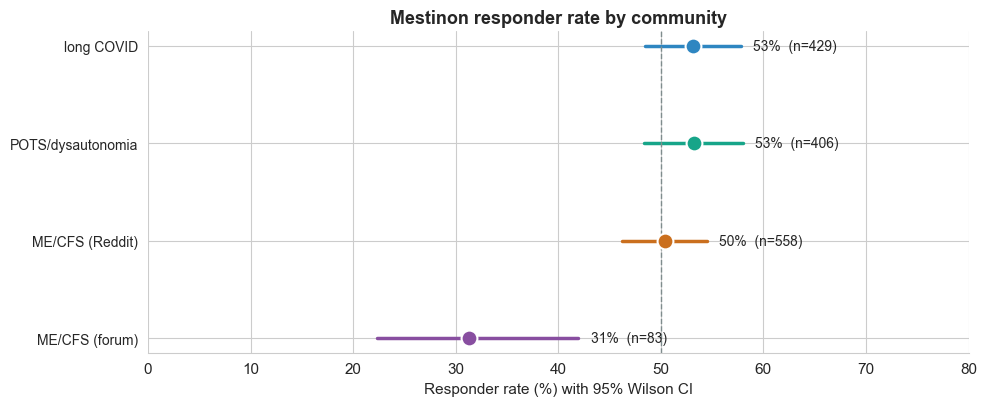

**What this shows.** Three of four communities cluster at **50–53%**, spanning very different conditions (long COVID, POTS, ME/CFS) — so the *condition* isn't what drives the rate. The ME/CFS forum (Phoenix Rising) runs lower at 31%, which §4 and §6 explain as selection and tolerability, not biology. The honest read: roughly **half of real-world users report meaningful benefit** — a real signal, not above chance at the patient level, and exactly the preliminary-evidence profile the RFI's Scenario 2 describes.

## 4. Non-response is about tolerability and dosing — not a patient type

We modeled response against patient and regimen features (full analysis in the companion notebook). **No baseline phenotype predicted response** (logistic pseudo-R² = 0.12); the only clean, actionable signal was *how the drug was used* — titrating the dose upward nearly tripled the odds (OR 2.8). Across communities, response falls as side-effect burden rises:

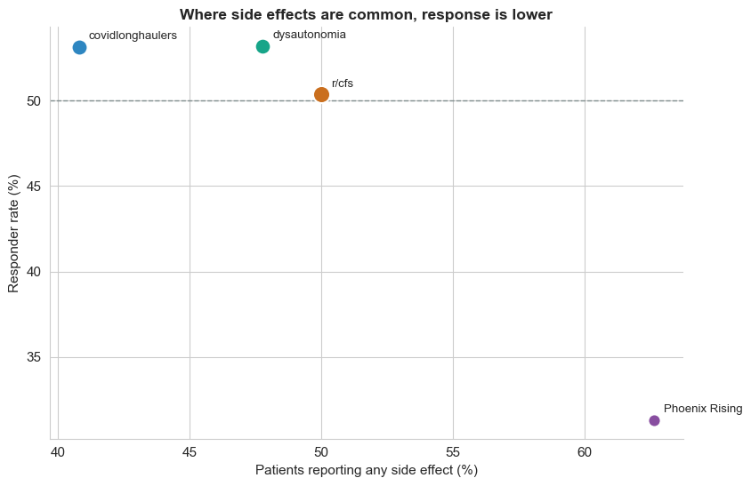

**Why this matters for a trial.** If apparent "non-response" is largely under-titration, intolerance, and early dropout, then the observational ~50% *understates* the drug — a fixable design problem. It tells a confirmatory trial exactly what to control: slow titration, multi-daily dosing, active side-effect management, and an adequate minimum duration before scoring failure. (Correlational, with reverse-causation limits — the data raises this question more sharply than it can answer it.)

## 5. LDN shows a parallel signal in the same populations

In the largest cohort where we ran both drugs (covidlonghaulers), LDN and Mestinon are statistically indistinguishable — a second off-patent candidate with the same real-world profile.

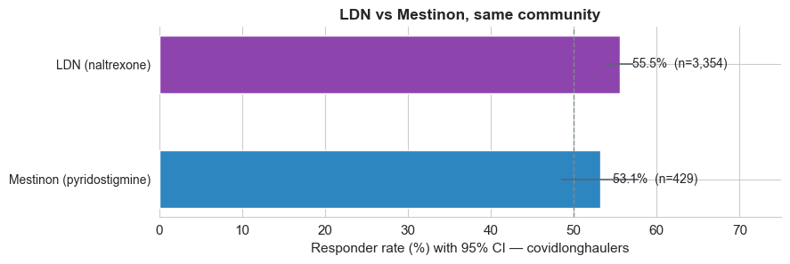

**LDN 55.5%** (n=3,354) vs **Mestinon 53.1%** (n=429) in the same corpus: 2-proportion z=0.93, **p=0.35** — no detectable difference. LDN is a second, independently-used off-patent candidate with a comparable signal, in the same unmet-need populations (not the fibromyalgia literature alone).

## 6. Real-world dosing and access barriers (our own pipeline)

Computed by us across all four corpora from raw post text — not borrowed. Two things bear directly on the off-patent/market-failure theme.

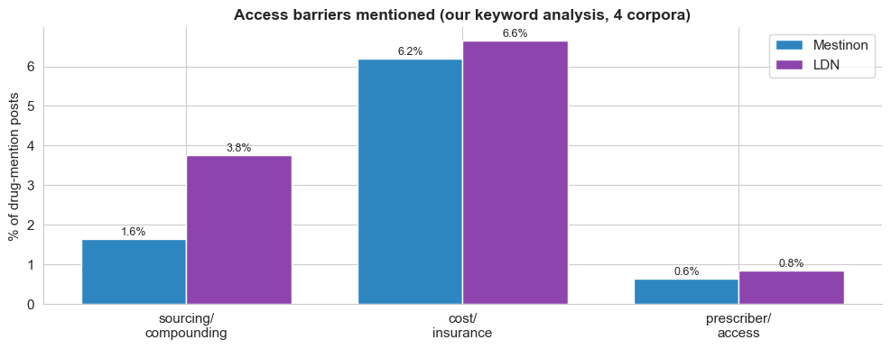

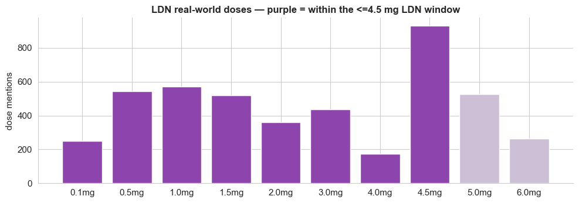

**LDN's compounding/sourcing barrier (3.8%) runs ~2.4x Mestinon's (1.6%)** — exactly the dosage-form gap: **80% of 5,336 LDN dose mentions are ≤4.5 mg**, a strength with no approved product, so patients must compound. Mestinon's real-world doses (30/60 mg, plus the 180 mg ER form) sit inside its approved range. Cost is the most-cited barrier for both (~6%). Keyword heuristics — directional, strongest for the relative LDN-vs-Mestinon contrast and the (clean, numeric) dose distribution.